# Project2

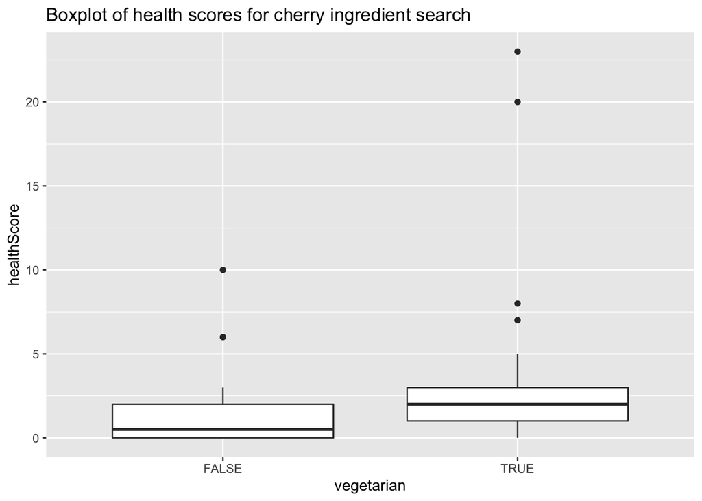

```r
g <- ggplot(ingredient_test, aes(x=vegetarian, y=healthScore))
g + geom_boxplot() +
  labs(title =  "Boxplot of health scores for cherry ingredient search")
```

The plots show a smaller spread of the calorie results for vegetarian recipes and some high outliers in the health scores for some of the vegetarian results with cherry as an ingredient.  
One more thing that we could look at are the histogram distributions of calories for the calorie search and health score for the ingredient search results to see if any interesting distributions arise.

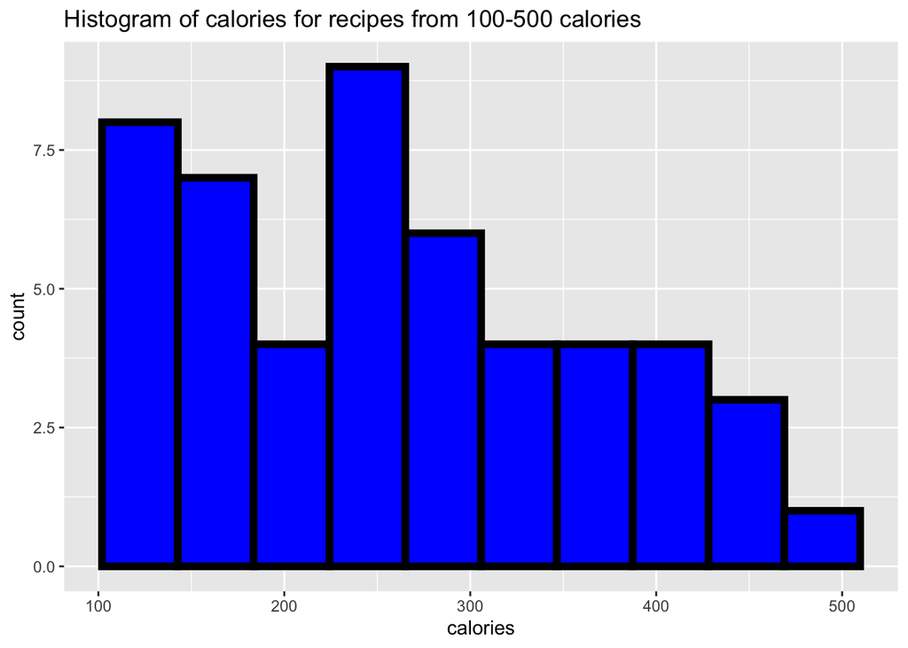

```r
#Now, here are some histograms
g <- ggplot(calorie_test, aes(x=calories))
g + geom_histogram(bins=10, color = "black", fill = "blue",
size = 2) +
  labs(title="Histogram of calories for recipes from 100-500 calories")
```

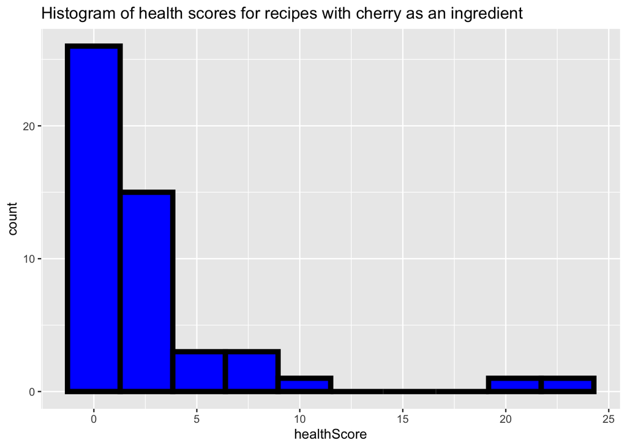

```r
g <- ggplot(ingredient_test, aes(x=healthScore))
g + geom_histogram(bins=10, color = "black", fill = "blue",
size = 2) +
  labs(title="Histogram of health scores for recipes with cherry as an ingredient")
```

The histograms show the results are skewed to the right in both distributions with peaks at relatively low numbers of calories and health scores.

# Conclusion

We hope that this vignette has given you some insight into working with APIs. In summary, what we did throughout this vignette was build some functions to allow for some flexible user defined searches, ran a few example searches, and did some exploratory data analysis with the results of those searches. Once the functions are built, there is nearly endless data that can be explored. Happy searching!

[output not shown]